# Your Digest for Sunday, Jan 28, 2024 11:59 PM

- Refers to the appearance of signs and symptoms of a disease progressively earlier and earlier in successive generations.
- Typical of diseases caused by a trinucleotide repeat.
- These are sequences of 3 nucleotides which repeat. *The number of repeats can increase from one generation to the next*, *making the DNA more and more unstable*. Accumulation of these repeats is called *trinucleotide repeat expansion.*
1. [[General medicine 6-Neurology#Muscular dystrophies and myotonia|Myotonic dystrophy]] - #autosomalDominant ; commonest dystrophy in europeans.
2. Huntington's chorea
3. Fragile X - the commonest form of **autism** of *known cause*.  
   | disease | Repeat sequence | Usually start with C and end with G |  
   | ---- | ---- | ---- |  
   | Huntington | CAG | "hunt for CAGE" |  
   | Friedrich Ataxia | GAA | two As in the name, fag |  
   | Myotonic dystrophy | CTG | T in the name |  
   | Fragile X | CGG | G in the name |

> [!TIP] mnemonic  
> Fraxe, Fragile, Friedrich have mad spinal dances  
> mad - myotonic dystrophy  
> dances - Huntington's chorea

> 3. **Increasing afterload OR preload** **DECREASES** *HOCM* and *MVP* murmur.

## Presentations of MS

- Usually has a area of 4cm2.
- Narrowing of upto 2 cm2 -> patients are asymptomatic.
- Severe symptoms when area :down to 1cm2.
- Symptoms: dyspnoea - due to pulmonary oedema.
- Blood tinged cough - rupture of pulmonary arteries / or haemoptysis.
- Features of secondary right heart failure.
- Enlarged atrium -> AF, left atrial thrombi, emboli,
- Commonest cause is **rheumatic carditis**.
- Signs: Mitral facies (due to formation of arteriovenous anastomoses).
- Active filling plays a bigger part in ventricular filling -> *presystolic accentuation* of the murmur.
- Loud P2 after development of pulmonary hypertension.
- Can have P mitrale with bifid P wave.
- MS murmur = best heart in expiration, at apex.
- Graham steele murmur. (an early *diastolic murmur*)
  - Graham Steell murmur: soft, blowing, decrescendo early diastolic murmur of pulmonary incompetence caused by *pulmonary hypertension*

[Good resource](https://www.kidneypathology.com/English_version/Histologic_patterns.html)

Source - UpToDate

- **FSGS** - Focal areas of mesangial collapse and sclerosis.
- *Causes*: Idiopathic, **HIV** infection, previous glomerular disease, massive obesity.
- In FSGS, disctintion between *primary and secondary FSGS* is important as treatment differs
- Clinical picture is ==more towards nephritic== in *secondary* FSGS.
- FSGS **recurs in transplanted kidneys**.
- Corresponding with the *focal nature* of the sclerosis, most of the affected glomeruli are at the level of the corticomedullary junction; so **superficial biopsies can miss the affected glomeruli** .
- Haematuria is commoner in FSGS than in MCD.
- MCD shows *selective protein loss* -> i.e mainly albumin and not higher molecular weight proteins like immunoglobulins. FSGS shows *non-selective proteinuria*.
- FSGS shows poor response to corticosteroids.
- Higher percentage of FSGS patients go on to develop CKD (50%). (adults have worse prognosis)
- MCD and FSGS both show minimal / no immune deposits.
- FSGS : FSGS changes are visible on light microscopy. MCD: few changes visible on light microscopy.

> [!INFO] Migraine pathogenesis is associated with **serotonin**. Some drugs used to treat migraine act on serotonin receptors.  
> Serotonin receptors have several subtypes.

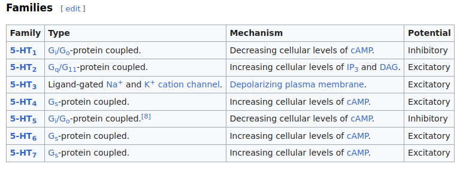

> [!TIP] Mnemonic: All the eponymous murmurs are diastolic murmurs  
> Austin flint - AR (austin aorti)  
> Graham steele - PR (Steeple - steele and P)  
> Carey coombs - acute RF (coo for a*cu*te)

See also: [[Basic Sciencies - MCQ reading#Dynamic auscultation]]

- Graham Steele murmur : **Graham Steell murmur:** soft, blowing, decrescendo early diastolic murmur of pulmonary incompetence caused by pulmonary hypertension
- The **kidney is the most commonly involved visceral organ** in SLE - Medscape. About **50% develop clinically evident renal disease**.
  - Lupus nephritis: immune complex nephritis showing full house pattern (with IgG, M, A and complement)
  - Presents with a mixed picture.
  - Histology: complex. See UpToDate. [Source](https://www.uptodate.com/contents/lupus-nephritis-diagnosis-and-classification?search=lupus%20nephritis&source=search_result&selectedTitle=1~150&usage_type=default&display_rank=1#H2713063806) (too complicated to read)
  - passMedicine: "The *most common histological pattern seen in lupus nephritis* is **diffuse proliferative glomerulonephritis**." (at least in the more severe cases)

# Heart failure

# Heart failure with preserved ejection fraction (EF >= 50%)

> **The clinical manifestations of HFpEF are generally the same** as those for other forms of HF

## Comparison of therapy in preserved EF and reduced EF.

| Reduced EF | Preserved EF |
| --- | --- |
| First line RX: ACEi Beta blocker | ACEi and beta blocker **do not** provided survival benefit. |
| Second line: Spironolactone SGLT-2 inhibitor |  |
| 3rd line: Ivabradine Sacubitril valsartan Digoxin Hydralazine + nitrate Cardiac resynchronization therapy |  |

# Cauda equina symdrome

- Can be **acute** or **chronic**. (chronic CE will cause atrophy)
- Is an **emergency** -> Needs surgical decompression.
- *Usually caused by a disc prolapse*; but neoplasms can also present this way.
  - Or LP causing haematoma
> - This is at the level at the **transpyloric plane**.
- Faecal incontinence with reduced rectal sphincter tone (anal sphinter is controlled by S2,S3,S4 - keep the poo off the floor")

> "VPA is **widely used in pediatric epilepsy** because of its multiple mechanisms of action and acceptable **safety profile**" [Source](https://www.ncbi.nlm.nih.gov/pmc/articles/PMC3696515/)

Low toxicity; Non sedative.

- **Stabilization of voltage gated Na channels**.
- **Increases GABA levels**. (GABA is made by the **TCA cycle** and valproate inhibits enzymes which degrade it).

> This binding extends the inactivated phase and inhibits the generation of rapid action potentials when the cell is experiencing incoming depolarizing trains - i.e **stabilizes voltage gated sodium channels**

***